# Does firing rate depend on 3D position within caudoputamen?

Exploration-confirmation analysis of Brain Wide Map exact-CP units

## Original question

The original question was: **How does firing rate depend on 3D position within CP?**

Here, CP means caudoputamen / striatum units labeled with the exact atlas acronym `CP` in a local Brain Wide Map ephys dataset. The outcome is each good unit’s stored whole-session firing rate, analyzed as `log10(firing_rate)`.

## Introduction

The caudoputamen is a large striatal structure. A single summary across all CP units can hide spatial heterogeneity, because different probes sample different anterior-posterior, medial-lateral, and dorsal-ventral parts of the structure. The analysis therefore asked whether mean firing rate varies systematically with 3D anatomical coordinate inside CP.

The main risk was overinterpreting exploratory spatial structure. Probe trajectories, subject/session composition, and uneven anatomical coverage can all produce apparent gradients. To reduce this risk, the project used a subject-level exploration/confirmation split chosen before inspecting held-out firing rates.

## Refinement of the question

### Dataset and metric

The analysis used exact-CP units with canonical good-unit labels. Unit coordinates were converted to micrometers. The coordinate convention used here is:

- `x`: medial-lateral coordinate;
- `y`: anterior-posterior coordinate;
- `z`: dorsal-ventral coordinate, where less negative `z` is more dorsal.

Stored firing rate was used as a provisional direct metric of whole-session unit firing. Two stored firing-rate surfaces agreed essentially exactly in the exploration set: the maximum absolute difference between the unit metadata firing rate and the unit-feature firing rate was `4.1e-6 Hz`.

Whole-session firing rate is a broad and useful summary, but it can mix anatomy with state, drift, or sorting stability. This caveat matters for interpretation.

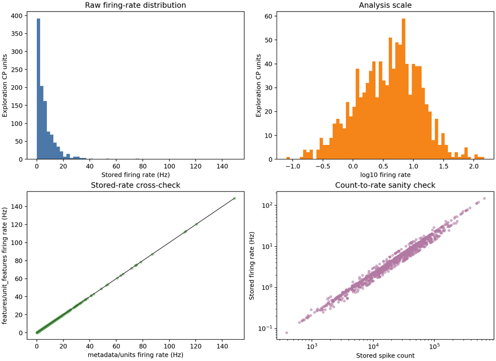

Metric diagnostics. Raw firing rates were right-skewed, so `log10(firing_rate)` was used. The two stored firing-rate columns agreed essentially exactly.

### Exploration-confirmation split

The split was by subject. Before further firing-rate analysis, CP coverage was optimized using only exact-CP channel coordinates and replicate metadata, not firing rates. The locked exploration set contained 11 of 44 subjects, selected to preserve 3D CP coverage in both exploration and confirmation sets.

The final split had a worst-set covering radius of about `489 um`, much better than typical random 25% subject splits.

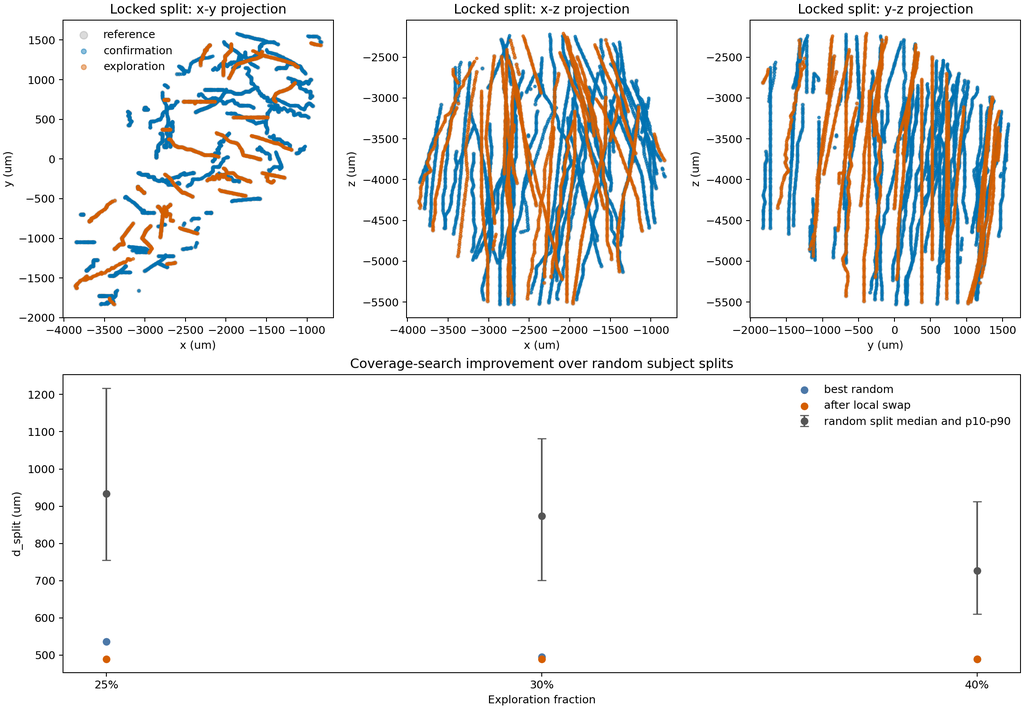

Coverage-balanced subject split diagnostics. The split was optimized using CP coordinate coverage only, before firing-rate analysis.

### Exploratory spatial structure

Exploration used 1,075 exact-CP units from 11 subjects, 23 sessions, and 25 probes. All units had good-unit labels.

The first exploratory spatial plots suggested three possible patterns:

1. A negative anterior-posterior (`y`) trend: more anterior probe locations tended to have lower mean firing rate.
2. A positive dorsal-ventral (`z`) trend: more dorsal units tended to have higher firing rate.
3. Possible nonuniform local structure beyond a simple linear gradient.

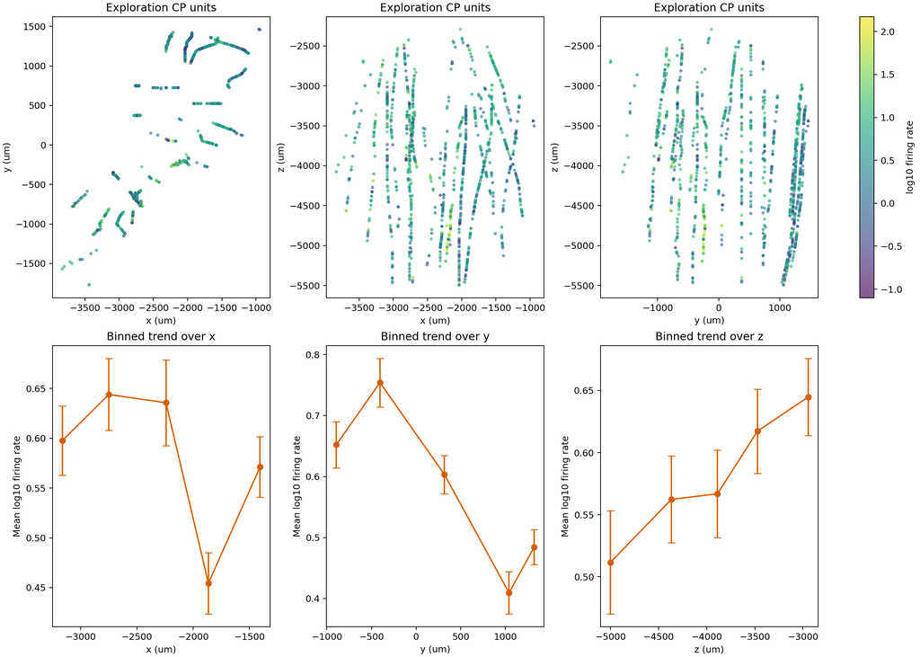

Exploration-only spatial plots. Binned trends suggested a strong `y` trend and a weaker positive `z` trend.

Probe-level diagnostics changed the interpretation. The `z` trend was modest but usually positive within probes: 14 of 19 eligible exploration probes had positive within-probe Spearman correlations between `z` and `log10(firing_rate)`. In contrast, the global `y` trend was not a within-probe effect: eligible probes had limited `y` span, and exploration subjects did not span both low and high `y` tertiles.

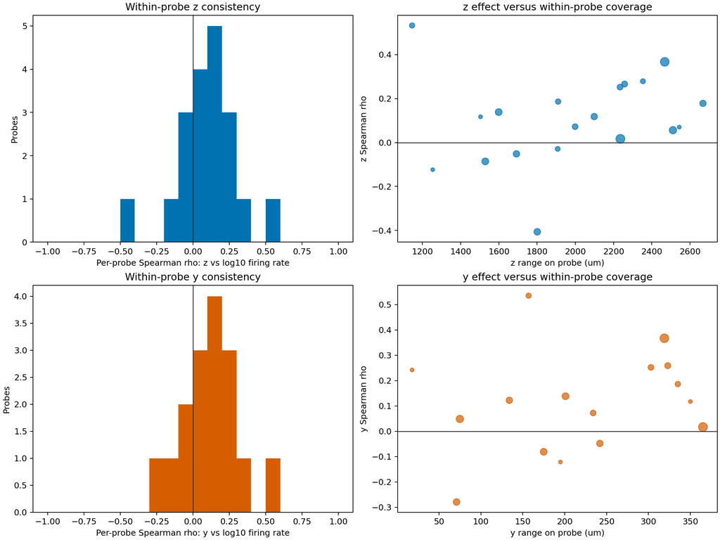

Probe-level consistency. The `z` trend could be assessed within probes; the `y` trend was mainly between probes because within-probe AP span was small.

The between-probe `y` trend was visually clear when each probe was reduced to one point, but this was a between-probe association and could still be confounded by other spatial coverage variables.

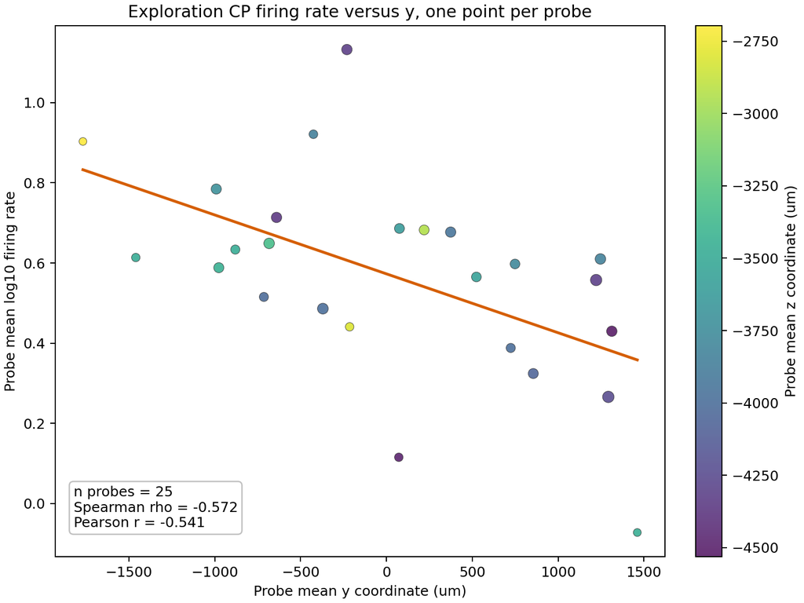

Exploration-only probe mean firing rate versus probe mean `y`. Each point is a probe; color shows probe mean `z`.

### Choosing the confirmatory statistic

Several candidate confirmatory tests were compared on the exploration set only. A continuous within-probe `z` statistic was better than a high-versus-low tertile contrast. The tertile contrast was retained only as an interpretable sensitivity analysis.

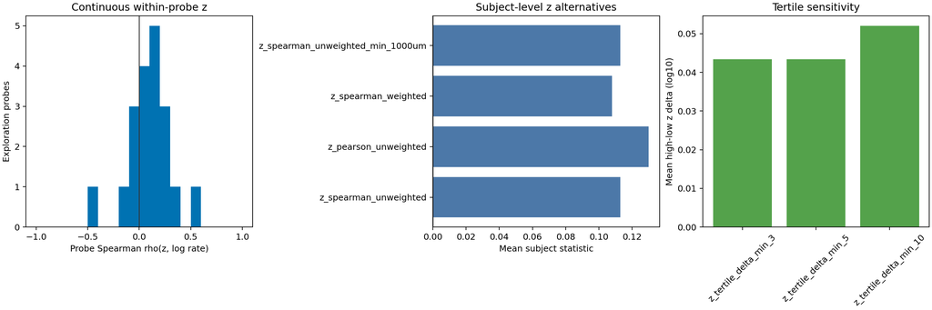

Exploration-only comparison of candidate confirmatory statistics. Continuous within-probe `z` correlations retained more information than high-versus-low tertile deltas.

The final primary confirmatory question became:

> Across held-out sessions, are within-probe correlations between dorsal-ventral coordinate and log firing rate shifted above zero?

## Locked analysis plan

### Primary confirmatory test

For each eligible confirmation probe:

```
rho_z_probe = Spearman correlation(z_um, log10_firing_rate)
```

Eligible probes had at least 15 exact-CP units and nonzero `z` variance.

For each session, probe correlations were Fisher-z transformed and averaged:

```
session_z_stat = mean(FisherZ(rho_z_probe)) across eligible probes in the session
```

The primary test was a one-sided Wilcoxon signed-rank test of whether session-level statistics were shifted above zero.

This session aggregation was chosen because probes recorded in the same session are not independent. A subject-aggregated analysis was planned as a more conservative sensitivity check.

### Sensitivity tests

Preplanned sensitivity analyses were:

- one-sided t-test across session statistics;
- subject-aggregated Wilcoxon and t-test;
- unit-count-weighted session and subject aggregation;
- Pearson correlation instead of Spearman correlation;
- high-versus-low `z` tertile contrast across subjects.

### Secondary `y` test

The `y` hypothesis was treated as secondary and between-probe. The planned model had one row per eligible probe:

```
probe mean log10(firing_rate) ~ mean_y + mean_x + mean_z
```

The coefficient for mean `y` was tested descriptively with subject-cluster bootstrap uncertainty. This was not treated as a within-subject AP gradient because coverage was inadequate for that design.

## Confirmatory results

### Primary `z` result

The held-out confirmation set contained 1,817 exact-CP units from 31 subjects, 48 sessions, and 51 probes. Thirty-four probes met the primary `z` eligibility rule and were aggregated to 31 session-level statistics.

The primary dorsal-ventral hypothesis was **not confirmed**:

- mean session Fisher-z statistic: `0.020`, approximately rho `0.020`;
- median session statistic: `0.031`;
- direction count: 19 positive and 12 negative sessions;
- primary one-sided Wilcoxon p-value: `0.132`.

The confidence interval for the mean session statistic crossed zero (`[-0.049, 0.082]`), and the t-test sensitivity was also not significant (`p = 0.280`).

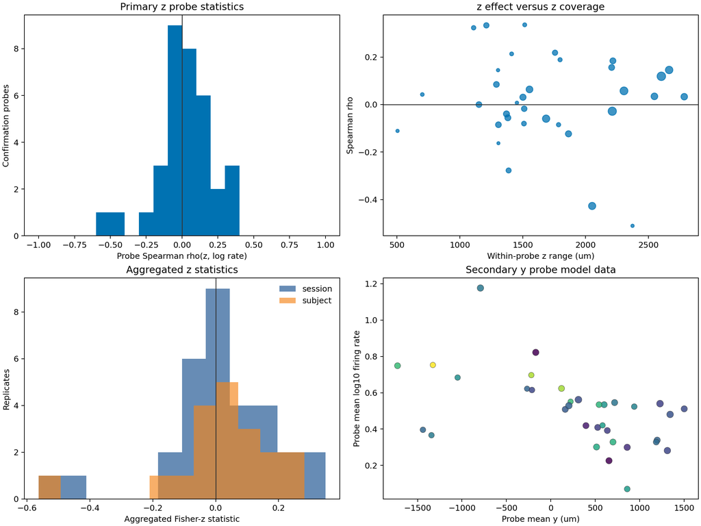

Confirmatory results. The held-out within-probe `z` statistics were centered only slightly above zero and did not confirm the exploratory dorsal-ventral trend.

Sensitivity analyses were consistent with the primary result:

| Analysis | Result |
| --- | --- |
| Session-aggregated Wilcoxon, primary | p = 0.132 |
| Session-aggregated t-test | p = 0.280 |
| Subject-aggregated Wilcoxon | p = 0.072 |
| Subject-aggregated t-test | p = 0.299 |
| High-versus-low `z` tertile sensitivity | p = 0.425 |

The subject-aggregated Wilcoxon sensitivity was directionally more favorable than the primary analysis, but it remained above the usual 0.05 threshold and was not the locked primary test.

### Secondary `y` result

The between-probe `y` effect remained directionally negative in the confirmation set. The unadjusted probe-level Spearman correlation between probe mean `y` and probe mean log firing rate was `-0.577`.

However, after adjusting for probe mean `x` and `z`, the coefficient was uncertain:

- adjusted coefficient for mean `y`: `-0.117` log10 units per SD;
- subject-cluster bootstrap interval: `[-0.252, 0.045]`.

Thus, the `y` result remains suggestive but was not confirmed under the preplanned adjusted model.

## Post-hoc analyses

No new post-hoc analyses were conducted after the confirmatory result. The figures above include preplanned sensitivity and secondary outputs generated by the locked confirmatory script.

The main post-confirmation interpretation is negative: the exploratory dorsal-ventral pattern did not reliably reproduce under the held-out subject split. The secondary AP pattern may deserve a more targeted future study, but this analysis does not establish it.

## Discussion

The project illustrates why the exploration-confirmation split mattered. Exploration suggested a dorsal-ventral CP firing-rate gradient, and the continuous within-probe statistic looked better than a coarse tertile contrast in the exploration set. But the held-out confirmation set produced a much smaller effect and a non-significant primary p-value.

The best-supported conclusion is therefore:

> In this BWM exact-CP dataset and with this whole-session firing-rate metric, the exploratory evidence for a dorsal increase in CP firing rate did not replicate in the locked confirmation set.

The secondary AP trend is more ambiguous. It appeared strongly in probe means, both in exploration and in unadjusted confirmation summaries, but the model-adjusted estimate had a bootstrap interval crossing zero. Because AP coverage is largely between probes and between subjects, that trend is vulnerable to insertion trajectory and spatial coverage confounds.

### Caveats

- The firing-rate metric is whole-session firing rate. It may mix anatomical firing-rate differences with behavioral state, recording stability, drift, or sorting effects.
- Coordinates were raw CCF-like unit coordinates, not CP-normalized coordinates. A future analysis could explicitly normalize within CP boundaries.
- Exact-CP inclusion excludes border-adjacent units. That was conservative for anatomical specificity, but it may omit relevant striatal border regions.
- The split was optimized for anatomical coverage rather than being a purely random subject split. This improves coverage but should be described as a coverage-balanced holdout.
- The negative confirmatory result does not prove no spatial structure exists. It says that the locked exploratory dorsal-ventral hypothesis was not confirmed by the chosen whole-session firing-rate test.

### Lessons for future AI-assisted analyses

This project produced two workflow lessons:

1. Test candidate confirmatory statistics on the exploration set before locking the held-out analysis. Here, that showed that continuous within-probe correlations were preferable to tertile contrasts.
2. When multiple probes can occur in one session, define whether inference is probe-, session-, or subject-level before running the confirmatory test. Averaging probe statistics within session was a better match to the dependence structure than treating probes as independent.

Suggested durable instruction additions are recorded in `suggested_instruction_updates.md` in this report directory. No instruction files were edited.

## Reproducibility

Project artifacts are organized under the project directory:

- exploration scripts and figures in `exploratory-analyses/`;
- split and exploration-unit artifacts in `artifacts/`;
- confirmatory plan, script, results, and figure in `confirmatory-analyses/`;
- this report in `report/`.

The key confirmatory output is `confirmatory-analyses/006_confirmatory_results_summary.json`.